# Programación Computacional para las Ciencias Sociales (CPO3522)

Andrés Cruz Labrín W 2019-04-01 III. Visualización de datos (diapos #1) [[Link a la hoja de ruta del curso]](https://docs.google.com/document/d/1Y0m0ExZfTO0EZe9JTGVOesNSWqiqnQFMAwCXhmHvzpA/edit?usp=sharing)

# Índice

1. Desarrollo del curso
2. Repaso: cadenas de operaciones en bases de datos
3. Ejercicio
4. Nuevo tema: visualización de datos

# El último ejercicio que hicimos

# Base de datos

```r
datos_qog
```

```
## # A tibble: 139 x 8
##    pais          pib     pob  corr perc_musulman polity2 region      pib_pc
##    <chr>       <dbl>   <dbl> <dbl>         <dbl>   <dbl> <chr>        <dbl>
##  1 Afghan…   5.76e10  3.07e7     8        99.3     2.02  Southern A…  1876.
##  2 Albania   2.87e10  2.90e6    31        20.5     8.08  Southern E…  9911.
##  3 Algeria   5.08e11  3.82e7    36        99.1     4.25  Northern A… 13301.
##  4 Angola    1.52e11  2.34e7    23         0       3.25  Middle Afr…  6503.
##  5 Austra…   9.90e11  2.31e7    81         0.200  10     Australia … 42830.
##  6 Austria   3.73e11  8.48e6    69         0.600  10     Western Eu… 44038.
##  7 Bahamas   8.50e 9  3.78e5    71         0      10     Caribbean   22490.
##  8 Bahrain   5.66e10  1.35e6    48        95       0.833 Western As… 41932.
##  9 Bangla…   4.47e11  1.57e8    27        85.9     6.42  Southern A…  2843.
## 10 Barbad…   4.33e 9  2.83e5    75         0.200  10     Caribbean   15339.
## # … with 129 more rows
```

# Enunciado

- Usando una sola cadena de *pipes*, obtén el total de habitantes musulmanes por región, y luego ordena las regiones desde la que tiene más musulmanes en total hasta la que tiene menos. Tip: no tenemos una variable con los habitantes musulmanes de un país, pero podemos crearla…
  1. Crear la variable con el total de habitantes musulmanes (`mutate()`), utilizando la población total y el porcentaje de musulmanes.
  2. Agregar/colapsar la variable por región (`group_by()` + `summarize()`). Tenemos que *sumar* los datos dentro de cada región.
  3. Ordenar las regiones decrecientemente según su total de habitantes musulmanes (`arrange()`).

# Solución en código

```r
datos_qog %>%
  # 1)
  mutate(n_musulmanes = pob * perc_musulman / 100) %>%
  # 2)
  group_by(region) %>%
  summarize(n_musulmanes = sum(n_musulmanes)) %>%
  # 3)
  arrange(-n_musulmanes)
```

```
## # A tibble: 21 x 2
##    region             n_musulmanes
##    <chr>                     <dbl>
##  1 Southern Asia        567554694.
##  2 Western Asia         164239654.
##  3 Northern Africa      159730728.
##  4 Western Africa       157205029.
##  5 South-Eastern Asia   132696751.
##  6 Eastern Asia          32617149.
##  7 Eastern Africa        30024747.
##  8 Middle Africa         11871851.
##  9 Northern America       2742930.
## 10 Western Europe         2343964.
## # … with 11 more rows
```

# Miniejercicio

- Accede a la [base de datos de aprobación presidencial](https://docs.google.com/spreadsheets/d/1PACuJD8DyQZkj_Ow-1i7l0CHL4TTpKCkgOw8LosLXtg/edit?usp=sharing) con la que hemos estado trabajando, en Google Sheets.
- Luego, mira el ejercicio en la [asistencia de hoy](https://docs.google.com/forms/d/e/1FAIpQLScQuhWaYAWkxX9Y5S1WBnhMSJZjfuqKjicKXkfSY8XUnUc15g/viewform?usp=sf_link).
- Ahora ingresa a RStudio Cloud. Puedes tipear [rstudio.cloud](https://rstudio.cloud/) en el navegador o acceder a través de la [hoja de ruta del curso](https://docs.google.com/document/d/1Y0m0ExZfTO0EZe9JTGVOesNSWqiqnQFMAwCXhmHvzpA/edit?usp=sharing).
  - El proyecto es el último del tema “02 - Manejo de bases de datos”.

# Nuevo tema: visualización de datos

# ¿Por qué visualizar datos? (I)

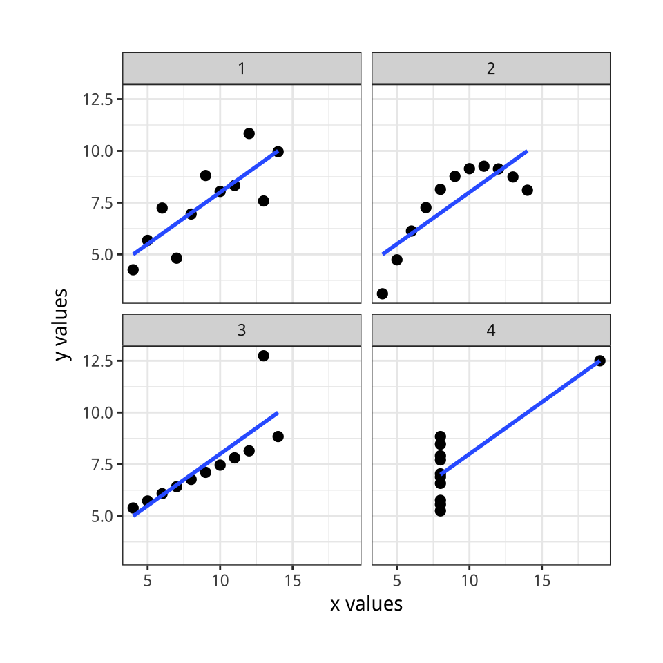

Cuarteto de Anscombe. Fuente: [Healy (2018)](http://socviz.co/), adaptado de Anscombe (1973).

# ¿Por qué visualizar datos? (II)

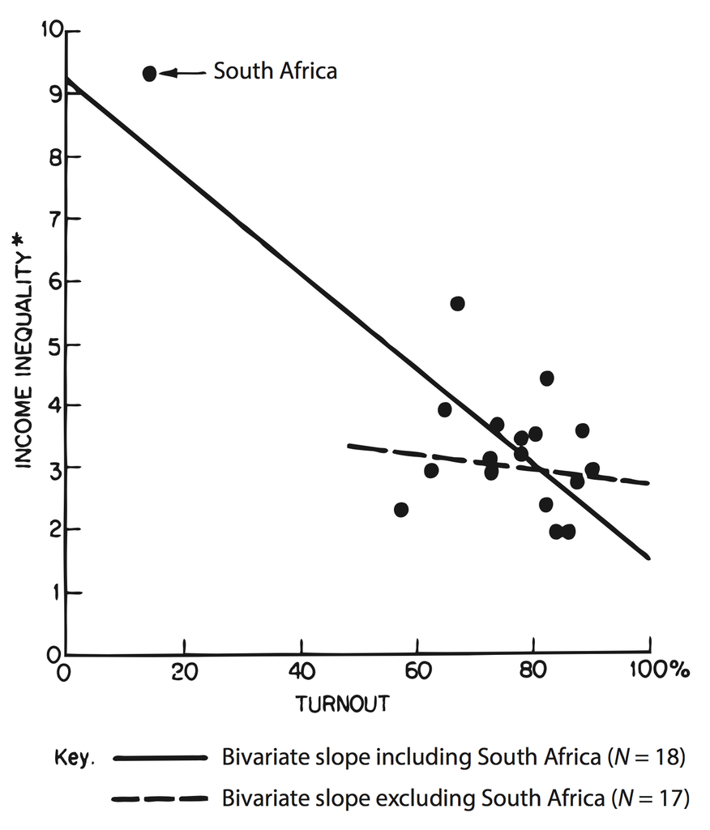

Fuente: Jackman (1980) en [Healy (2018)](http://socviz.co/).

# [[¿Por qué visualizar datos? (III)]](https://www.nytimes.com/interactive/2018/03/19/upshot/race-class-white-and-black-men.html)

# Gráficos en R con la gramática de gráficos

# Componentes de un gráfico en la “gramática de gráficos” (gg)

- 1. Base de datos. (2) Sistema de coordenadas. (3) Objetos geométricos o *geoms*.
- Los *geoms* se posicionan en el sistema de coordenadas de acuerdo a cómo mapeamos distintas **propiedades estéticas** a las variables de la base de datos (x, y, color, fill, etc.).

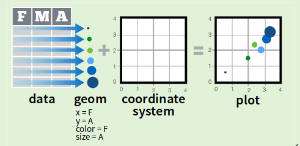

Fuente: [RStudio (2016)](https://docs.google.com/viewer?url=https://github.com/rstudio/cheatsheets/raw/master/translations/spanish/ggplot2.pdf)

# Tipos de gráficos

- Hay decenas de tipos de gráficos.
- En general, los podemos clasificar en dos tipos: univariados o bivariados.
  - Los univariados describen distribuciones, los bivariados muestran gráficamente la relación entre dos variables.
  - En general los distinguimos según si sus variables son discretas o continuas.

# Gráfico univariado para variables discretas: barras

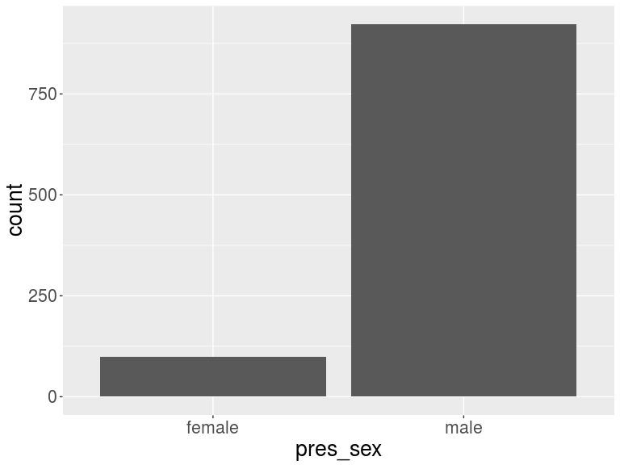

```r
ggplot(data    = datos_aprob,
       mapping = aes(x = pres_sex)) +
  geom_bar()
```

# Gráfico univariado para variables continuas: histograma (I)

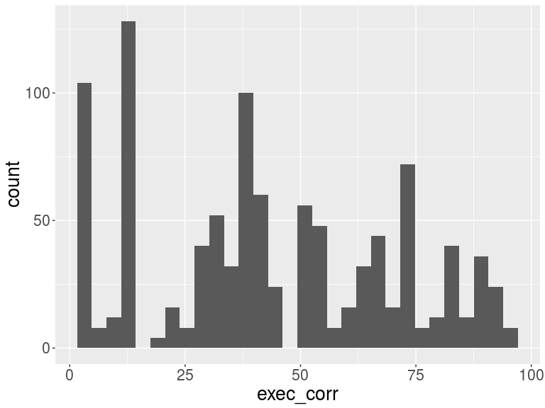

```r
ggplot(data    = datos_aprob,
       mapping = aes(x = exec_corr)) +
  geom_histogram()
```

# Gráfico univariado para variables continuas: histograma (II)

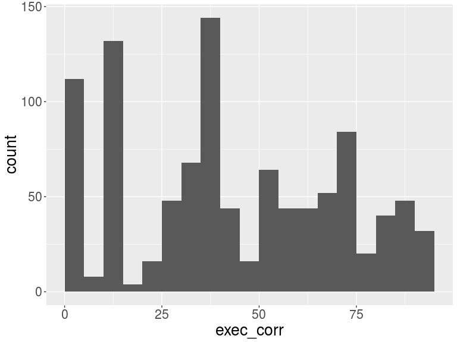

```r
ggplot(data    = datos_aprob,
       mapping = aes(x = exec_corr)) +
  geom_histogram(binwidth = 5, boundary = 0, closed = "left")
```

# [[Los primers de RStudio Cloud]](https://rstudio.cloud/learn/primers/)